# §1.5b — The Formation of the Moon: Angular Momentum and the Solar System

Unit 1: Intro to the Cosmos · Astronomy

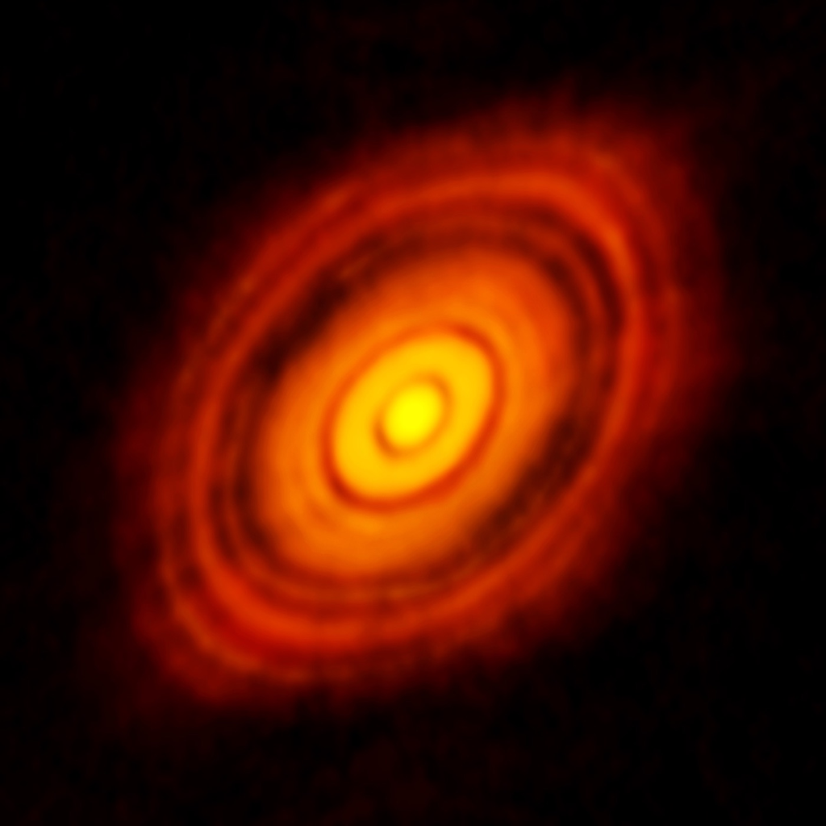

This is a real picture, not a drawing. A young star called HL Tauri, about 450 light-years away, sits inside a flat, spinning **disk** of gas and dust. The dark rings are gaps, probably cleared by planets that are forming right now.

Our solar system looked like this 4.56 Gyr ago. That is why every planet goes around the Sun the same way, in the same flat plane. But a cloud in space starts out as a lumpy blob, not a disk. So how does a blob become a pancake?

Today: angular momentum and hydrostatic equilibrium, how they build a solar system, and then: where did the Moon come from?

HL Tauri. ALMA (ESO/NAOJ/NRAO), CC BY 4.0

## 1 · The numbers at a glance

☀️

4.56 Gyr

Age of the solar system

when a cloud of hydrogen started to collapse

🔄

8 of 8

Planets orbit counter-clockwise

seen from above Earth's North Pole, all the same way

📏

under 7°

Tilt of every planet's orbit

the whole solar system is nearly flat, like a record

⛸️

Angular momentum

it is conserved: a spin cannot just go away

## 2 · Formation of the solar system and the Moon

Click a tile.

[figure not shown]

1

Angular Momentum

why a skater speeds up

[figure not shown]

2

Hydrostatic Equilibrium

kids and teachers

[figure not shown]

3

Formation of the Protoplanetary Disk

shrink, spin up, flatten

[figure not shown]

4

Nebular Hypothesis

build it step by step

[figure not shown]

5

The Evidence Tonight

the planets line up in our sky

[figure not shown]

6

Where Did the Moon Come From?

four ideas: which one? Lab 4

← scroll the tiles →

### Angular Momentum

Why does a skater speed up when she pulls her arms in? Anything spinning carries **angular momentum**, $L$. Angular momentum is **conserved**: nothing can add to it or take it away unless something twists the spinner.

$$L = I\omega \qquad\qquad I = mr^2 \qquad\qquad I_1\omega_1 = I_2\omega_2$$

**$I$, Moment of Inertia:** resistance to changing spin rate (kg m²). **$\omega$, spin rate** (degrees/sec). Mass far from the spin axis (big $r$) means a big $I$.

The skater, seen from above

[interactive chart not shown]

Armsinout

Her spin rate is 180°/sec with her arms out. Pull them in: $I$ gets smaller, so $\omega$ must get bigger to keep $L$ the same.

Ex. Spinning Dumbbell

Two 5 kg balls spin 4 m from the center of a (very light) rod at $\omega_1 = 30^\circ$/sec. They are moved outward to 6 m. What is the new spin rate?

[interactive chart not shown]

**A.** Moment of inertia before.

**Reveal**

$I_1 = 2\,(5\ \text{kg})(4\ \text{m})^2 = \boxed{160\ \text{kg m}^2}$ (two balls, so two $mr^2$)

**B.** Moment of inertia after.

**Reveal**

$I_2 = 2\,(5\ \text{kg})(6\ \text{m})^2 = \boxed{360\ \text{kg m}^2}$

**C.** The new spin rate.

**Reveal**

$I_1\omega_1 = I_2\omega_2 \;\Rightarrow\; (160)(30) = 360\,\omega_2 \;\Rightarrow\; \omega_2 = \boxed{13.3^\circ/\text{sec}}$. Mass moved out, so it spins slower.

Your turn: pull the masses in

Two 3 kg balls spin 2 m from the center at $\omega_1 = 45^\circ$/sec. They are pulled in to 1 m.

| $I_1$ before | kg m² |
| --- | --- |
| $I_2$ after | kg m² |
| $\omega_2$ | °/sec |

### Hydrostatic Equilibrium: Kids and Teachers

In the beginning, 4.56 Gyr ago, there was a **hydrogen cloud**. Think of it as a kindergarten class. **Heat is "the kids"**: atoms flying around from being hot, bumping into each other, create an outward **pressure**. **Gravity is "the teachers"**: trying to pull everybody back together.

**Hydrostatic Equilibrium:** Inward $F_{\rm gravity}$ = Outward Pressure from heat. When they balance, the cloud keeps its size.

High energy is "after snack": bouncing off the walls, not enough space for everyone. Low energy is "naptime": everybody nestled together, lots of space.

Slowly the cloud radiates away energy. What happens?

Predict first. The cloud will get:

[interactive chart not shown]

red arrows: pressure from heat (kids) · blue arrows: gravity (teachers)

The cloud is in hydrostatic equilibrium: the arrows balance.

### Formation of the Protoplanetary Disk

The cloud must be spinning, at least a little: nothing in space is perfectly still. As the cloud cools it gets smaller, but its spin doesn't go away. Big cloud, little spin, becomes **small cloud, lots of spin**. That is $I_1\omega_1 = I_2\omega_2$ again.

Spin also flattens it. Around the middle, the spin holds the gas out. Along the spin axis nothing holds it up, so the cloud falls in from the top and bottom and squashes into a spinning **protoplanetary disk**. At the center it gets hot and dense enough for **fusion**: a star turns on.

Collapse a spinning cloud

The cloud shrinks to $\tfrac{1}{10}$ of its size. Predict: it now spins

[interactive chart not shown]

Ex. Relative form: the shrinking cloud

**A.** The cloud shrinks to $\tfrac{1}{10}$ of its size. By how many times does $I = mr^2$ change? (Same mass.)

**Reveal**

$I = mr^2 = (1)\left(\tfrac{1}{10}\right)^2 = \boxed{\tfrac{1}{100}\ \text{times as big}}$

**B.** By how many times does the spin rate change?

**Reveal**

$L = I\omega$ stays the same, so if $I$ is $\tfrac{1}{100}$ as big, $\omega$ must be $\boxed{100\ \text{times as fast}}$.

Why a disk? Spin only holds things up in the plane

A spinning cloud cut in half and seen from the side: the spin axis goes up and down, the midplane goes across, the protostar is in the middle. Each dot is a parcel of gas, all the same distance from the axis. Drag the green one anywhere.

Predict first. A parcel above the midplane will:

[interactive chart not shown]

**⟶** gravity, toward the center**- - ›** its in-plane part, toward the axis**⟶** its vertical part, toward the midplane**⟶** spin pushes out, away from the axis

[figure not shown]

**A protoplanetary disk**, artist's concept: the new star in the middle, the spinning disk of gas and dust around it. NASA/JPL-Caltech

### Nebular Hypothesis

Put it together and you get the **nebular hypothesis**: the Sun and planets formed from one spinning cloud. Build one step by step, then zoom in on how dust grows into planets.

Build a solar system, step by step

[interactive chart not shown]

[figure not shown]

Zoom out: from dust grains to planets

[interactive chart not shown]

Each step on the scale bar is a factor of 10 in size (an order of magnitude). The pictures are drawn, not to scale; the bar is.

Telescopes see every step happening around other stars.

[figure not shown]

**1. A giant molecular cloud.** Cold hydrogen gas and dust. New stars are forming inside these pillars. NASA, ESA, CSA, STScI

[figure not shown]

**2. Disks around new stars.** Protoplanetary disks in the Orion Nebula; bottom right is seen almost edge on. M. McCaughrean (MPIA), C. R. O'Dell (Rice), NASA/ESA

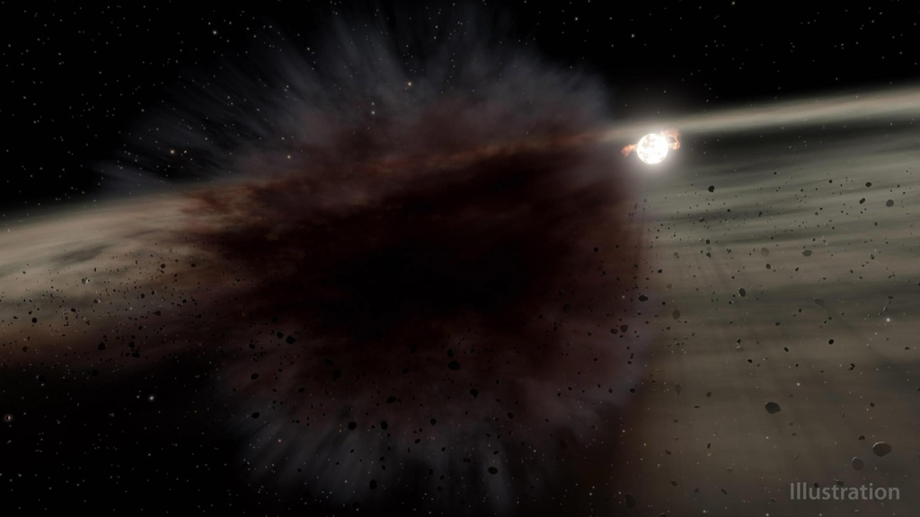

**3. Clumps collide and grow.** Dust sticks into rocks, rocks into **planetesimals**, and those smash together into planets (artist's view). NASA/JPL-Caltech

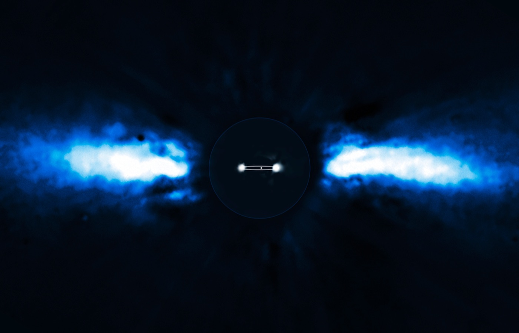

**4. Planets in the leftover disk.** β Pictoris, 63 light-years away: an edge-on disk with a young planet, β Pic b, inside it. ESO/A.-M. Lagrange

**5. Today:** eight planets, all going around the Sun the same way, all in nearly the same plane. The spin and the flat disk are still there, 4.56 Gyr later.

### The Evidence Tonight

Here is where the Sun, the Moon and the planets actually were on Thursday night, all the way around the sky. The gold line is the **ecliptic**, the path the Sun follows through the stars. Look at where everything sits compared with it.

The whole sky along the ecliptic, Thu Oct 15, 2026

[interactive chart not shown]

Positions computed with Astronomy Engine for 9 pm PDT. The up-and-down scale is stretched 5× so you can see anything off the line at all. Even so, nothing strays more than about 8°.

That is a lot of things on one line. Some planets are close to us and some are 30 AU away, in every direction. So why do they all show up along the same line? Pick an idea. Then go look at the real solar system on the same night, in 3D.

The solar system in 3D, on the same night

Predict: from Earth, the planets all sit near one line in the sky. Why?

[interactive chart not shown]

Loading the 3D view…

date

**Test your idea**

- Stand on Earth. Drag to look around the whole sky.
- Show the plane, from above, edge on, and from Earth.
- Slide the date a few months either way. Does anything ever leave the gold line?

**Go look (from Portland, Oct 15–16, 2026)**

- **Saturn** rises in the east at 6:05 pm and is highest in the south at 12:15 am. Up all night.
- **Mars and Jupiter** rise at 1:00 am and 2:05 am. Before school (6:30 am) they are high in the southeast, about 12° apart.
- **Venus** is lost in the Sun's glare: it passes between us and the Sun on Oct 23. **Mercury** is too low after sunset to see.
- Sketch Saturn, Mars and Jupiter with the Moon or bright stars nearby. Notice they all sit along one arc across the sky.

### Where Did the Moon Come From?

The Moon is weird: it is about a quarter of Earth's size, far bigger for its planet than almost any other moon. There are four ideas for where it came from.

Sister Planet

The Moon formed next to Earth, at the same time, from the same part of the disk.

Captured Asteroid

The Moon formed somewhere else and Earth's gravity captured it as it passed.

Fission Fragment

The young Earth spun so fast that a piece of it flew off.

Giant Impact

A Mars-sized body hit the young Earth. Rock from the outer layers splashed out into a ring that clumped into the Moon.

Earth and Moon cut open, to scale

[interactive chart not shown]

Earth's iron core is over half its radius. The Moon's is tiny. The Moon is made almost entirely of rock like Earth's outer layers.

**Which one is it?** That is Lab 4. You will be the scientists: test each idea against real data from Apollo rocks, lunar orbiters and meteorites, then make your case in a one-page lab report.

## 3 · Put the solar system together

Drag the steps into order, first at the top (on a phone, drag by the ⋮⋮ handle), or use the arrows.

First at the top, last at the bottom

## 4 · Self-check

**Sources and further reading**

Want to dig deeper? Each title links straight to the original.

**Disks around young stars**

- [Planets forming around HL Tauri](https://www.eso.org/public/news/eso1436/) (ESO/ALMA): the press release behind the picture at the top, and why the gaps point to planets.
- [Protoplanetary disks in the Orion Nebula](https://esahubble.org/images/opo9545b/) (ESA/Hubble): the 1995 pictures that first showed disks around newborn stars.
- [A planet inside the β Pictoris disk](https://www.eso.org/public/news/eso1024/) (ESO): a young planet caught moving around its star.
- [Webb's Pillars of Creation](https://esawebb.org/images/weic2216a/) (ESA/Webb): new stars forming inside a cold cloud of gas and dust.

**How the solar system formed**

- [Solar system facts](https://science.nasa.gov/solar-system/solar-system-facts/) (NASA): how the Sun and planets formed from a spinning cloud 4.6 billion years ago.
- [Planetary Fact Sheet](https://nssdc.gsfc.nasa.gov/planetary/factsheet/) (NASA): every planet's orbit, including how far each one is tilted.
- [Astronomy Engine](https://github.com/cosinekitty/astronomy) (Don Cross): the free code used to place the planets for Oct 15, 2026.

**Where the Moon came from**

- [How the Moon formed](https://science.nasa.gov/moon/formation/) (NASA): the giant impact idea and the evidence for it.
- [Moon facts](https://science.nasa.gov/moon/facts/) (NASA): the Moon's size, density and its small iron core.
- [Oxygen in Moon rocks matches Earth's](https://doi.org/10.1126/science.aad0525): lab measurements on Apollo samples. Young et al. 2016, Science

**Image credits**

HL Tauri (eso1436a), ALMA (ESO/NAOJ/NRAO), CC BY 4.0. β Pictoris and β Pic b (eso1024a), ESO/A.-M. Lagrange, CC BY 4.0. Protoplanetary disks in the Orion Nebula (opo9545b), Mark McCaughrean (Max-Planck-Institute for Astronomy), C. Robert O'Dell (Rice University), and NASA/ESA, CC BY 4.0. Pillars of Creation (weic2216a), NASA, ESA, CSA, STScI; J. DePasquale, A. Koekemoer, A. Pagan (STScI), CC BY 4.0. Planetesimal collision around HD 166191, illustration (PIA25161), NASA/JPL-Caltech. Protoplanetary disk artist concept (PIA20645), NASA/JPL-Caltech. The skater, the clouds, the sky strip and the Earth and Moon cutaway are drawn on the page.